# Building augmented data for multi-state models

The **msmtools** workflow

Francesco Grossetti francesco.grossetti@unibocconi.it

2026-06-01

```r
library(msmtools)
library(data.table)
library(msm)
```

# 1 Overview

**msmtools** prepares longitudinal data for multi-state models fitted with **msm** (Jackson 2011, 2016). The package exposes four public functions:

- `augment()` builds transition-level data from repeated observations;
- `polish()` removes subjects with incompatible transitions at the same time;
- `survplot()` compares fitted and empirical survival curves;
- `prevplot()` compares observed and expected state prevalences.

The examples below use the bundled `hosp` dataset. It contains synthetic hospital admissions for 10 subjects.

```r
data(hosp)
hosp[1:6, .(subj, adm_number, gender, age, label_3, dateIN, dateOUT, dateCENS)]
```

```
##     subj adm_number gender   age label_3     dateIN    dateOUT   dateCENS
##    <int>      <int> <fctr> <int>  <char>     <Date>     <Date>     <Date>
## 1:     1          1      F    83 dead_in 2008-11-30 2008-12-12 2011-04-28
## 2:     1          2      F    83 dead_in 2009-01-26 2009-02-16 2011-04-28
## 3:     1          3      F    83 dead_in 2009-05-13 2009-05-15 2011-04-28
## 4:     1          4      F    83 dead_in 2009-05-20 2009-05-25 2011-04-28
## 5:     1          5      F    83 dead_in 2009-06-12 2009-06-16 2011-04-28
## 6:     1          6      F    83 dead_in 2009-06-20 2009-06-25 2011-04-28
```

# 2 Data Augmentation

`augment()` adds one row per transition endpoint and creates status variables that can be used directly in an **msm** model.

```r
hosp_augmented <- augment(
  data = copy(hosp),
  data_key = subj,
  n_events = adm_number,
  pattern = label_3,
  t_start = dateIN,
  t_end = dateOUT,
  t_cens = dateCENS
)
hosp_augmented[
  1:8,
  .(subj, adm_number, label_3, augmented, augmented_int, status, status_num)
]
```

```
## Key: <subj, adm_number>
##     subj adm_number label_3  augmented augmented_int status status_num
##    <int>      <int>  <char>     <Date>         <int> <char>      <int>
## 1:     1          1 dead_in 2008-11-30         14213     IN          1
## 2:     1          1 dead_in 2008-12-12         14225    OUT          2
## 3:     1          2 dead_in 2009-01-26         14270     IN          1
## 4:     1          2 dead_in 2009-02-16         14291    OUT          2
## 5:     1          3 dead_in 2009-05-13         14377     IN          1
## 6:     1          3 dead_in 2009-05-15         14379    OUT          2
## 7:     1          4 dead_in 2009-05-20         14384     IN          1
## 8:     1          4 dead_in 2009-05-25         14389    OUT          2
```

When the input time columns are `Date` values, `augment()` keeps the date-valued transition time and adds an integer version. This is useful because **msm** works with numeric time scales.

```r
names(hosp_augmented)
```

```
##  [1] "subj"          "adm_number"    "gender"        "age"
##  [5] "rehab"         "it"            "rehab_it"      "label_2"
##  [9] "label_3"       "augmented"     "augmented_int" "dateIN"
## [13] "dateOUT"       "dateCENS"      "status"        "status_num"
## [17] "n_status"
```

# 3 Outcome Schema And Generated States

`pattern` and `state` describe different parts of the augmentation. `pattern` is the terminal outcome schema observed in the input data. It can have two values, alive and dead, or three values, alive, dead during a transition, and dead after a transition.

`state` is the generated transition-state vocabulary. It must always contain three labels: the state at `t_start`, the state at `t_end`, and the absorbing state. This is why a two-value `pattern` still needs three `state` labels: `augment()` uses the event times to infer whether death maps to the absorbing state inside or outside the transition window.

By default, `augment()` uses `copy = FALSE` and follows **data.table** by-reference semantics. This avoids unnecessary memory use on large longitudinal datasets, but the input object can have its key changed and `n_events` can be created when the argument is omitted. Use `copy = TRUE` when the original input must remain unchanged.

# 4 Duplicate Transition Cleanup

`polish()` removes entire subjects when different transitions occur at the same time. The bundled data do not contain such conflicts, so this call leaves the data unchanged. It also uses `copy = FALSE` by default; set `copy = TRUE` when the original augmented data should not be keyed or otherwise touched by reference.

```r
hosp_clean <- polish(
  data = copy(hosp_augmented),
  data_key = subj,
  pattern = label_3
)

nrow(hosp_augmented)
```

```
## [1] 114
```

```r
nrow(hosp_clean)
```

```
## [1] 114
```

# 5 Survival Plot

The plotting helpers work on fitted **msm** objects. This example uses a compact three-state transition matrix matching the default `augment()` state labels.

```r
Qmat <- matrix(0, nrow = 3, ncol = 3, byrow = TRUE)
Qmat[1, 1:3] <- 1
Qmat[2, 1:3] <- 1
colnames(Qmat) <- c("IN", "OUT", "DEAD")
rownames(Qmat) <- c("IN", "OUT", "DEAD")

msm_model <- msm(
  status_num ~ augmented_int,
  subject = subj,
  data = hosp_augmented,
  exacttimes = TRUE,
  gen.inits = TRUE,
  qmatrix = Qmat,
  method = "BFGS",
  control = list(fnscale = 6e+05, trace = 0, REPORT = 1, maxit = 10000)
)
```

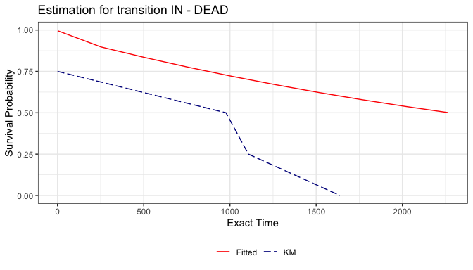

```r
surv_p <- survplot(msm_model, km = TRUE, grid = 10)
```

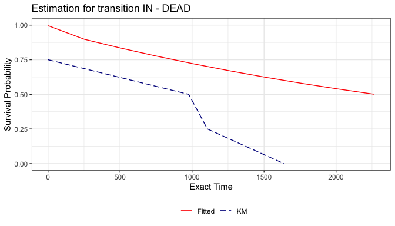

```r
surv_p
```

The fitted and Kaplan-Meier data tables are attached to the plot as named fields, accessible with the standard `$` operator:

```r
surv_p$fitted[1:6]
```

```
##      time      surv
##     <num>     <num>
## 1:    1.0 0.9957174
## 2:  252.7 0.8974193
## 3:  504.4 0.8343219
## 4:  756.1 0.7756608
## 5: 1007.8 0.7211242
## 6: 1259.5 0.6704220
```

```r
surv_p$km[1:6]
```

```
##    subject  time time_exact anystate    km
##      <int> <int>      <int>    <num> <num>
## 1:       5 13985          0        1  0.75
## 2:       6 14962        977        1  0.50
## 3:       1 15092       1107        1  0.25
## 4:       7 15623       1638        1  0.00
## 5:      NA    NA         NA       NA    NA
## 6:      NA    NA         NA       NA    NA
```

# 6 Prevalence Plot

`prevplot()` uses the output of `msm::prevalence.msm()` and returns a `ggplot` object.

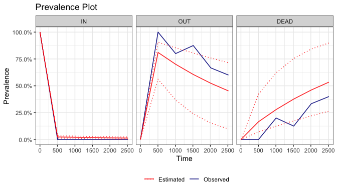

```r
prev <- prevalence.msm(
  msm_model,
  covariates = "mean",
  ci = "normal",
  times = seq(
    min(hosp_augmented$augmented_int),
    max(hosp_augmented$augmented_int),
    length.out = 6
  )
)

prev_p <- prevplot(msm_model, prev, ci = TRUE, M = FALSE)
```

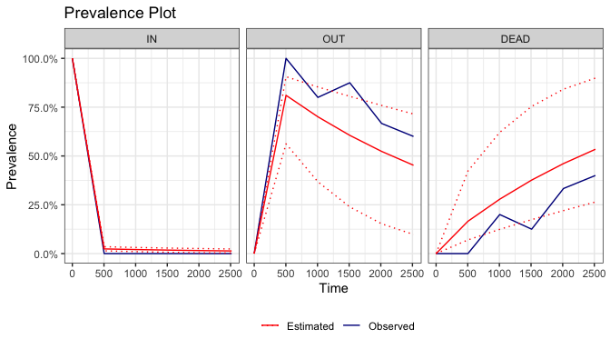

```r
prev_p
```

The long-format prevalence data used to build the plot is attached as `$prevalence`:

```r
prev_p$prevalence[1:6]
```

```
##     time  state   obs        hat         lwr        upr
##    <int> <fctr> <num>      <num>       <num>      <num>
## 1:     0     IN     1 1.00000000 1.000000000 1.00000000
## 2:   503     IN     0 0.02390625 0.013908807 0.03527887
## 3:  1006     IN     0 0.02066274 0.009993814 0.03133934
## 4:  1510     IN     0 0.01785929 0.006484496 0.02825379
## 5:  2013     IN     0 0.01543621 0.004331795 0.02575895
## 6:  2517     IN     0 0.01334188 0.002999964 0.02354828
```

# 7 Notes

The current 2.x series keeps the public API stable while modernizing dependencies, documentation, tests, and CI. Larger internal changes to `augment()` are intentionally deferred until after the maintenance releases.

Jackson, C. H. 2011. “Multi-State Models for Panel Data: The Msm Package for R.” *Journal of Statistical Software* 38 (8): 1–29.

———. 2016. *Msm: Multi-State Markov and Hidden Markov Models in Continuous Time*. https://cran.r-project.org/package=msm.